# Central limit theorem - simple example

NDH802

#### Research problem

Suppose we want to invetigate the cheating behaviors among the 360,000 Swedish students. The variable of interest is binary, to cheat or not to cheat. Each student takes ten exams in a school year. The probability of cheating is 10% (similarly applicable for all exams, all students).  
*Note*: These assumptions are purely hypothetical.

#### Data simulation

Normally, we don’t know the so-called *true* distribution, but for the sake of learning the CLT, let’s pretend we do to simulate data. Once we have created the data, we pretend (again) it’s not us who create it. Yes, two activities we often do when we learn statistics are to imagine and to pretend we know or don’t know things, depending on the questions.

Anyway, now you have a so-called population data that includes 360,000 rows like these. Each row represents a student with his/her ID and number of exams he/she cheated. For example, student #1 cheated on 1/10 exam(s), student #2 cheated on 1/10 exam, student #3 cheated on 0/10 exam(s), and so on. In case you’re wondering, it’s the same old binomial distribution.

```
##    studentID cheat
## 1          1     1
## 2          2     1
## 3          3     0
## 4          4     0
## 5          5     1
## 6          6     1
## 7          7     0
## 8          8     1
## 9          9     0
## 10        10     3
```

#### Sampling

If we have tons of time and resourses, we can investigate each and every student to answer our research question. Unfortunately, we don’t. No one does, most of the time. That’s when sampling comes to our rescue.

Now, we will randomly select 30 students from our population (i.e., our sample size N = 30), investigate the number of exams they have cheated. We’ll then have a report like this.

```r
#Taking samples from the population
pop[sample(1:nstudents, size = sample_size, replace = FALSE),]
```

```
##        studentID cheat
## 580          580     1
## 281874    281874     0
## 258501    258501     0
## 307737    307737     1
## 87909      87909     0
## 174288    174288     0
## 40657      40657     0
## 351139    351139     3
## 332705    332705     1
## 303485    303485     2
## 100721    100721     0
## 227857    227857     2
## 229504    229504     1
## 139669    139669     2
```

[output cut: 16 more lines]

Then, we calculate the mean of the cheated exams of these 30 students, which is:

```r
cat(mean(pop[sample(1:nstudents, size = sample_size, replace = FALSE),2]))
```

```
## 0.9333333
```

We repeat this process, say, 50 times. Then we’ll have 50 means, right? We then plot these 50 means in a histogram.

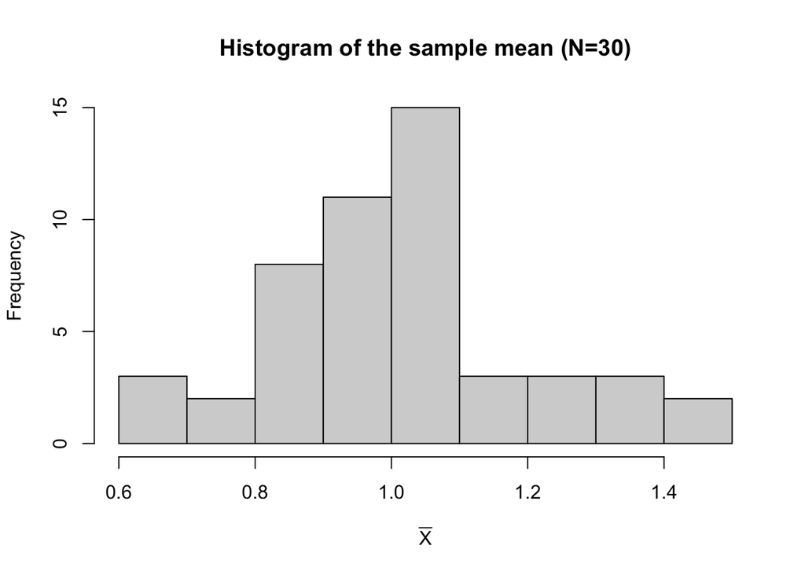

```r
#Taking samples from the population
sample_size = 30 #Number of students you draw out every time of investigation
nrep = 50 #You do it nrep times

sample_mean = rep(NA, nrep) #You don't need to learn to code this
set.seed(802)
for(i in 1:nrep) {
  #Here you randomly draw a sample_size students to investigate their behavior
  sample = pop[sample(1:nstudents, size = sample_size, replace = FALSE),]
  #then you compute the mean number of cheated exams (over nexam)
  sample_mean[i] = mean(sample$cheat)
}
hist(sample_mean, main = "Histogram of the sample mean (N=30)",
     xlab = expression(bar(X)))
```

Does it look somewhat familar to you? Hmm, not really. Let’s try increasing the sample size to sample size = 100 and repeat it 200 times. How about now? Ring any *bells*?

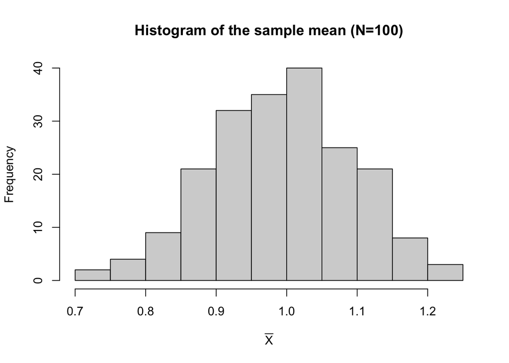

```r
sample_mean = rep(NA, nrep_200) #You don't need to learn to code this
for(i in 1:nrep_200) {
  #Here you randomly draw a sample_size students to investigate their behavior
  sample = pop[sample(1:nstudents, size = sample_size_100, replace = FALSE),]
  #then you compute the mean number of cheated exams (over nexam)
  sample_mean[i] = mean(sample$cheat)
}
hist(sample_mean, 15, main = "Histogram of the sample mean (N=100)",
     xlab = expression(bar(X)))
```

### Central limit theorem

If it reminds you of the bell curve, you are absolutely right. **The Central Limit Theorem suggests that when we have a huge number of observations, the **sample mean** follows a normal distribution.** Formally, when $n$ is large, $\bar{X_n} \sim N(\mu,\frac{\sigma^2}{n})$. Graphically, when when $n$ is large, the histogram will look more and more like the bell curve.

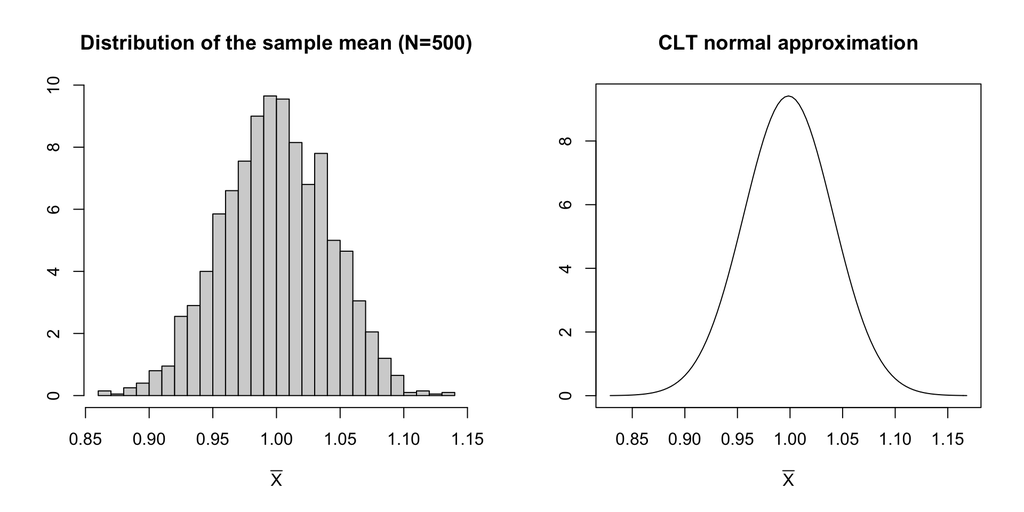

```r
prob_sample = sum(sample_mean < 1)/length(sample_mean)
prob_clt = pnorm(1, mean = mu, sd = sqrt(sigma_squared_clt))
```

So, $P(cheat<1)$ from our samples is 0.49 and from the CLT curve is 0.51. Pretty close. Let’s try another one, let’s compute $P(0.92<cheat<1.08)$.

```r
prob_sample = sum(sample_mean > 0.92 & sample_mean < 1.08 )/length(sample_mean)
prob_clt = pnorm(1.08, mean = mu, sd = sqrt(sigma_squared_clt)) - pnorm(0.92, mean = mu, sd = sqrt(sigma_squared_clt))
```

So, $P(0.92<cheat<1.08)$ from our samples is 0.95 and from the CLT curve is 0.94. Again, pretty close!

### Key takeaways

1. Distribution of the random variable $X$ is **different from** the distribution of the sample mean $\bar{X}$.
2. When the number of observations is large, the sampling distribution of the sample mean $\bar{X}$ converges (approximates) to the normal distribution $N(\mu,\frac{\sigma^2}{n})$, regardless of the distribution of $X$.

For example, the blue bars illustrate the number of cheated exams following binomial distribution, while the pink bars represent the **average** number of cheated exams (the **sample mean**), following normal distribution when the sample size is large.

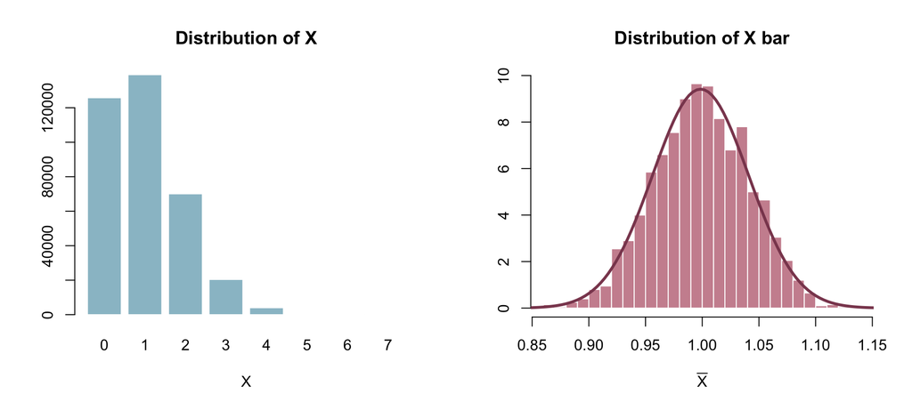

3. In reality, we normally don’t know the population distribution. Thanks to point (ii), we can infer the population mean $\mu$ from the sample mean $\bar{X}$.